# Exploratory Analysis Of Red-wine Dataset, by Daniel McBride

This report explores a dataset of characteristics of red wines. The dataset contains 13 characteristics of red wines with 1599 observations.

A discription of the dataset can be found here: https://s3.amazonaws.com/udacity-hosted-downloads/ud651/wineQualityInfo.txt

Dataset Citation: P. Cortez, A. Cerdeira, F. Almeida, T. Matos and J. Reis. Modeling wine preferences by data mining from physicochemical properties. In Decision Support Systems, Elsevier, 47(4):547-553. ISSN: 0167-9236.

# Initial Observations

```r
wi <- read.csv('C:/Users/Daniel/Documents/Udacity/EDA/project/wineQualityReds.csv')
head(wi)
```

|  | X | fixed.acidity | volatile.acidity | citric.acid | residual.sugar | chlorides | free.sulfur.dioxide | total.sulfur.dioxide | density | pH | sulphates | alcohol | quality |
| --- | --- | --- | --- | --- | --- | --- | --- | --- | --- | --- | --- | --- | --- |
| 1 | 1 | 7.4 | 0.70 | 0.00 | 1.9 | 0.076 | 11 | 34 | 0.9978 | 3.51 | 0.56 | 9.4 | 5 |
| 2 | 2 | 7.8 | 0.88 | 0.00 | 2.6 | 0.098 | 25 | 67 | 0.9968 | 3.20 | 0.68 | 9.8 | 5 |
| 3 | 3 | 7.8 | 0.76 | 0.04 | 2.3 | 0.092 | 15 | 54 | 0.9970 | 3.26 | 0.65 | 9.8 | 5 |
| 4 | 4 | 11.2 | 0.28 | 0.56 | 1.9 | 0.075 | 17 | 60 | 0.9980 | 3.16 | 0.58 | 9.8 | 6 |
| 5 | 5 | 7.4 | 0.70 | 0.00 | 1.9 | 0.076 | 11 | 34 | 0.9978 | 3.51 | 0.56 | 9.4 | 5 |
| 6 | 6 | 7.4 | 0.66 | 0.00 | 1.8 | 0.075 | 13 | 40 | 0.9978 | 3.51 | 0.56 | 9.4 | 5 |

```r
library(GGally)
library(scales)
library(memisc)
library(grid)
library(gridExtra)
library(ggplot2)
library(lattice)
library(MASS)
library(scales)
```

Not knowing much about high-quality wine, I decided to start with plotting each variable against each other, to see which variables correlated the highest with quality

[output not shown]

[output cut: 114 more lines]

[output not shown]

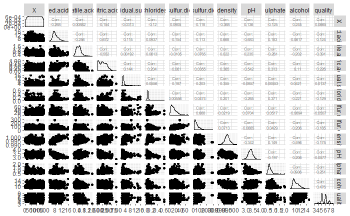

```r
ggpairs(wi, upper = list(continuous = wrap("cor", size = 2, hjust=0.8)))
```

From this ggpairs plot it looks like alcohol is the most correlated with quality followed by volatile acidity, then sulfates then citric acid. Since none of these are very highly correlated with quality. It’s fair to say that more than one variable must affect the quality of the wine. There must be some symbiotic relationships between the contents of the wine that contribute to higher quality.

# Univariate Analysis

In this section, we’ll do a surface level analysis of different variables in our dataset staring with quality.

```r
ggplot(data = wi, x = quality) +
  geom_histogram()
```

[output not shown]

Furthermore, since the quality data is supposed to range from 0 to 10, but we only use 3 through 8, I think it makes sense to transfrom the data from a 0 to 10 scale to a 0 to 5 scale

```r
summary(wi$quality)
```

```
   Min. 1st Qu.  Median    Mean 3rd Qu.    Max.
  3.000   5.000   6.000   5.636   6.000   8.000
```

```r
wi$quality = wi$quality-3
summary(wi$quality)
```

```
   Min. 1st Qu.  Median    Mean 3rd Qu.    Max.
  0.000   2.000   3.000   2.636   3.000   5.000
```

Plotting our transformed data:

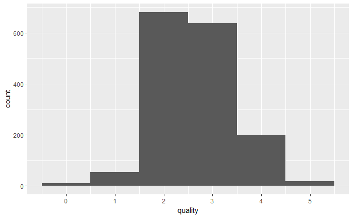

```r
ggplot(data = wi, aes(x = quality)) +
  geom_histogram(bins = 6) +
  scale_x_continuous(breaks = seq(0,5,1))
```

Now lets look at the distribution of alchohol in the dataset.

```r
summary(wi$alcohol)
```

```
   Min. 1st Qu.  Median    Mean 3rd Qu.    Max.
   8.40    9.50   10.20   10.42   11.10   14.90
```

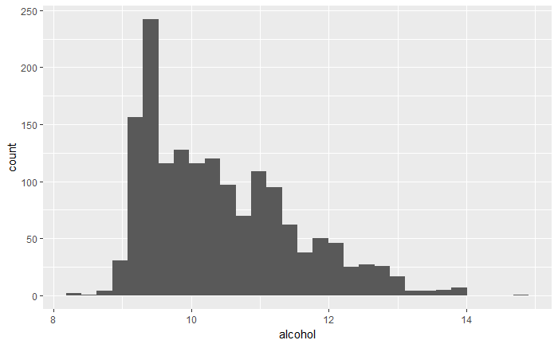

```r
ggplot(data = wi, aes(x = alcohol)) +
  geom_histogram()
```

Our alcohol percentage histogram is right-skewed. Let’s look at the alcohol percentage in a bit higher resolution.

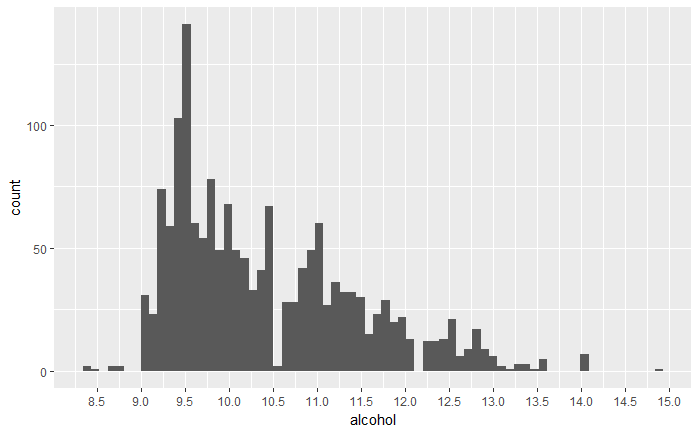

```r
ggplot(data = wi, aes(x = alcohol)) +
  geom_histogram(bins = 70) +
  scale_x_continuous(breaks = seq(8, 15, .5))
```

Alcohol percentage seems pretty spread out with most of the data between 9% and 12%, although there are a few outliers above 13.5%. This is suprising to me because I was under the impression that most wines were around 14% ABV.

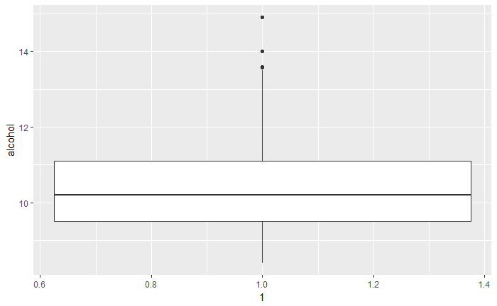

```r
ggplot(data = wi, aes(x = 1,y = alcohol)) +
  geom_boxplot()
```

Next lets look at volatile acidity

```r
summary(wi$volatile.acidity)
```

```
   Min. 1st Qu.  Median    Mean 3rd Qu.    Max.
 0.1200  0.3900  0.5200  0.5278  0.6400  1.5800
```

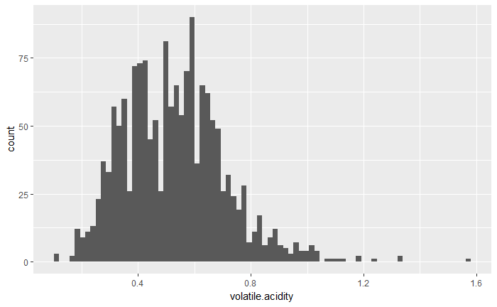

```r
ggplot(data = wi, aes(x = volatile.acidity)) +
  geom_histogram(bins = 80)
```

Volatile aciditiy seems to have a pretty normal distribution.

```r
summary(wi$sulphates)
```

```
   Min. 1st Qu.  Median    Mean 3rd Qu.    Max.
 0.3300  0.5500  0.6200  0.6581  0.7300  2.0000
```

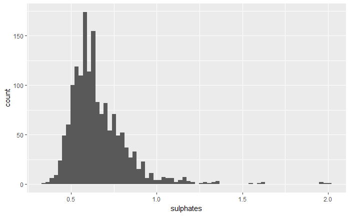

```r
ggplot(data = wi, aes(x = sulphates)) +
  geom_histogram(bins = 70)
```

```r
summary(wi$citric.acid)
```

```
   Min. 1st Qu.  Median    Mean 3rd Qu.    Max.
  0.000   0.090   0.260   0.271   0.420   1.000
```

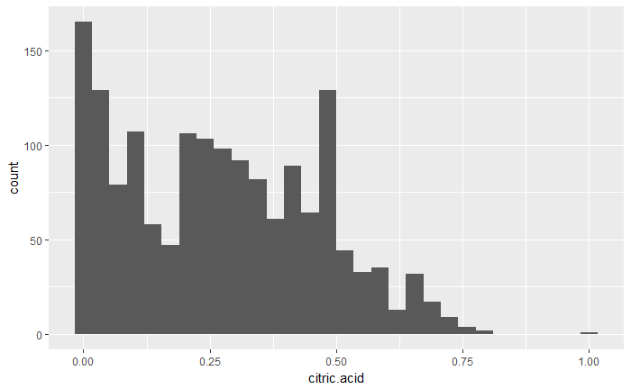

```r
ggplot(data = wi, aes(x = citric.acid)) +
  geom_histogram(bins = 30)
```

Citric acid seems to be spread out all over the place. Looks like it’s right-skewed, but it’s hard to tell.

```r
summary(wi$density)
```

```
   Min. 1st Qu.  Median    Mean 3rd Qu.    Max.
 0.9901  0.9956  0.9968  0.9967  0.9978  1.0037
```

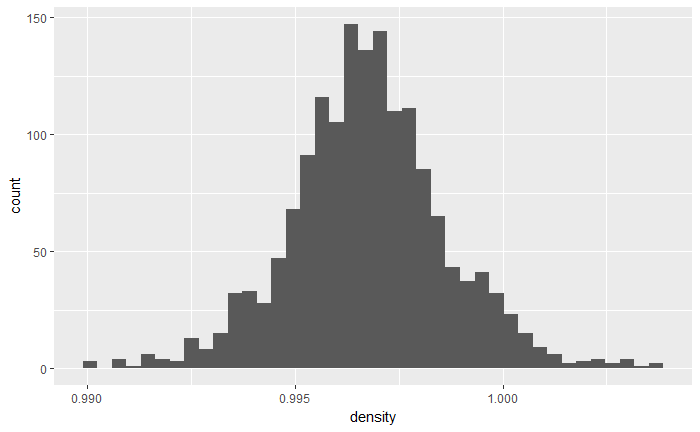

```r
ggplot(data = wi, aes(x = density)) +
  geom_histogram(bins = 40)
```

Density among the wines seems to have a very normal distribution.

```r
summary(wi$alcohol)
```

```
   Min. 1st Qu.  Median    Mean 3rd Qu.    Max.
   8.40    9.50   10.20   10.42   11.10   14.90
```

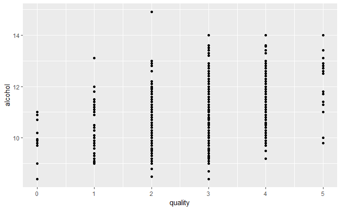

```r
ggplot(data = wi, aes(y = alcohol, x = quality)) +
  geom_point()
```